# Coverage of the confidence intervals of evSyn_CI()

A simulation study for the pooled results of a GORICA evidence synthesis

restriktor

2026-10-23

# 1 Aim

`evSyn_CI()` gives confidence intervals (CIs) for the pooled (final) results of a GORICA evidence synthesis: the pooled GORICA values, the differences in pooled GORICA values, the pooled GORICA weights, and the ratios of pooled GORICA weights. This simulation study evaluates the coverage of these CIs for the two available approaches:

- `method = "boot"` (default): parametric bootstrap, drawing per study from N(estimates, VCOV), independently over the studies, and taking percentiles of the pooled quantities;
- `method = "delta"`: normal-based (delta-method) CIs, with the covariance matrix of the pooled log-likelihood values as the sum of the study-specific ones (and the CIs of the weights on the logit scale).

# 2 Design

## 2.1 Data-generating model

Each study estimates three (standardized) parameters, say three group means with unit variance and $n$ observations per group. The estimates of study $s$ are drawn as $\hat\theta_s \sim N(\theta, V)$, with $V = \mathrm{diag}(1/n, 1/n, 1/n)$; this is exactly the (asymptotic) model underlying the GORICA. The studies are independent and have the same true parameters $\theta$ (no heterogeneity).

## 2.2 Hypotheses

Two sets of hypotheses are evaluated:

- **Set A**: $H_1: \theta_1 > \theta_2 > \theta_3$ and $H_2: \theta_1 > \theta_2 = \theta_3$, with the unconstrained hypothesis as failsafe (the default for more than one hypothesis);
- **Set B**: $H_1: \theta_1 > \theta_2 > \theta_3$ versus its complement (the default for one hypothesis).

## 2.3 Conditions

```r
thetas <- list(
  inside   = c(b1 = 0.4, b2 = 0.2, b3 = 0.0),  # in H1, not in H2
  boundary = c(b1 = 0.2, b2 = 0.0, b3 = 0.0),  # on the boundary of H1 and in H2: overlap
  outside  = c(b1 = 0.0, b2 = 0.2, b3 = 0.4),  # in the opposite order
  null     = c(b1 = 0.0, b2 = 0.0, b3 = 0.0)   # all equal
)
hypo_sets <- list(
  A = list(H1 = "b1 > b2 > b3", H2 = "b1 > b2 = b3"),  # failsafe: unconstrained
  B = list(H1 = "b1 > b2 > b3")                        # failsafe: complement
)
conditions <- expand.grid(theta = names(thetas), n = c(25, 100), S = c(3, 10),
                          type_ev = c("added", "equal"), hypo_set = names(hypo_sets),
                          stringsAsFactors = FALSE)
# The equal-evidence approach is only evaluated for set A (for the differences and
# ratios, it gives the same CIs as the added-evidence approach up to a constant).
conditions <- conditions[!(conditions$hypo_set == "B" & conditions$type_ev == "equal"), ]
rownames(conditions) <- NULL
nrow(conditions)
```

```
## [1] 48
```

This gives 48 conditions: 4 true parameter vectors $\times$ 2 sample sizes per group ($n$ = 25, 100) $\times$ 2 numbers of studies ($S$ = 3, 10) $\times$ the evidence-synthesis approach (added; equal for set A) $\times$ 2 sets of hypotheses. Each condition is replicated $R$ = 400 times, with $B$ = 500 bootstrap draws per study. With $R$ = 400, the Monte Carlo standard error of an estimated coverage of .95 is 0.011, so estimated coverages in between 0.928 and 0.972 are in line with a coverage of .95.

## 2.4 Estimand

As for `goric_CI()`, the population counterparts of the GORICA values are their *expected* values, $E[\mathrm{GORICA}_m] = \log|2\pi V| + E[D_m] + 2\,PT_m$, with $D_m$ the squared Mahalanobis distance of the estimates to $H_m$ and $PT_m$ the (fixed) penalty. For the pooled results (equal prior weights and equal study weights):

- added: $E[\mathrm{GORICA}^{pool}_m] = S \cdot E[\mathrm{GORICA}_m]$;
- equal: $E[\mathrm{GORICA}^{pool}_m] = S \cdot (E[\mathrm{GORICA}_m] - 2\,PT_m) + 2\,PT_m$ (log-likelihoods summed, penalty averaged).

The target values of the differences, the weights, and the ratios of weights follow from these expected pooled values. The expected values are obtained by Monte Carlo at the true parameters (100,000 draws).

```r
# Expected GORICA values (per hypothesis) for one study with estimates ~ N(theta, V)
expected_IC <- function(theta, V, hyps, nsim) {
  g <- goric(theta, VCOV = V, hypotheses = hyps)   # object at the true parameters
  models <- as.character(g$result$model)
  draws <- restriktor:::goric_CI_boot(g, models, B = nsim)
  list(EIC = colMeans(draws), PT = g$result$penalty)
}

# Target values for the pooled results (equal priors, equal study weights)
pooled_targets <- function(E, S, type_ev, pf = 2) {
  EIC <- if (type_ev == "added") S * E$EIC else S * (E$EIC - pf * E$PT) + pf * E$PT
  eta <- -EIC / 2
  w <- exp(eta - max(eta)); w <- w / sum(w)
  list(IC = EIC, weights = w,
       diff  = outer(EIC, EIC, "-"),          # [m, k] = IC_m - IC_k
       ratio = exp(outer(eta, eta, "-")))     # [m, k] = w_m / w_k
}
```

## 2.5 One replication

For each replication, $S$ studies are generated, `evSyn()` is run, and the CIs of both methods are computed. For each quantity, it is recorded whether the CI contains the target value, whether the CI is missing (the delta method gives no CI for a difference/ratio when the two hypotheses have the same order-restricted MLEs in *all* studies), and the width of the CI (on the log scale for ratios).

```r
one_rep <- function(cond, tg, B) {
  theta <- thetas[[cond$theta]]; hyps <- hypo_sets[[cond$hypo_set]]
  n <- cond$n; S <- cond$S
  V <- diag(1 / n, 3)
  est <- lapply(seq_len(S), function(s) setNames(theta + rnorm(3, 0, sqrt(1 / n)), names(theta)))
  r <- suppressMessages(evSyn(est, VCOV = rep(list(V), S), hypotheses = hyps, type_ev = cond$type_ev))
  out <- list()
  for (method in c("boot", "delta")) {
    ci <- suppressMessages(evSyn_CI(r, method = method, B = B))
    M <- nrow(ci$IC)
    # ratios and differences: hypothesis 1 (H1) versus the others
    for (k in 2:M) {
      j <- which(ci$ratio_weights$model == ci$IC$model[1] & ci$ratio_weights$vs == ci$IC$model[k])
      lo <- ci$ratio_weights$lower[j]; up <- ci$ratio_weights$upper[j]; tt <- tg$ratio[1, k]
      out[[length(out) + 1]] <- data.frame(method = method, quantity = "ratio",
        comparison = paste0("H1 vs. ", c("H2", "failsafe")[min(k - 1, 2)][1]),
        covered = !is.na(lo) && lo <= tt && tt <= up, missing = is.na(lo),
        width = if (is.na(lo)) NA else log(up) - log(lo))
      lo <- ci$difference$lower[j]; up <- ci$difference$upper[j]; tt <- tg$diff[1, k]
      out[[length(out) + 1]] <- data.frame(method = method, quantity = "difference",
        comparison = paste0("H1 vs. ", c("H2", "failsafe")[min(k - 1, 2)][1]),
        covered = !is.na(lo) && lo <= tt && tt <= up, missing = is.na(lo),
        width = if (is.na(lo)) NA else up - lo)
    }
    # weight of H1
    lo <- ci$weights$lower[1]; up <- ci$weights$upper[1]; tt <- tg$weights[1]
    out[[length(out) + 1]] <- data.frame(method = method, quantity = "weight", comparison = "H1",
      covered = !is.na(lo) && lo <= tt && tt <= up, missing = is.na(lo),
      width = if (is.na(lo)) NA else up - lo)
  }
  out <- do.call(rbind, out)
  # in set B, the second hypothesis is the failsafe (complement)
  if (cond$hypo_set == "B") out$comparison[out$comparison == "H1 vs. H2"] <- "H1 vs. failsafe"
  out
}
```

## 2.6 Running the simulation

The simulation is run in parallel over the replications (with `future.apply`). It is only run when the parameter `run_simulation` is `TRUE`; otherwise, the saved results are used.

```r
library(future.apply)
plan(multisession, workers = params$workers)
set.seed(2026)
res <- vector("list", nrow(conditions))
for (i in seq_len(nrow(conditions))) {
  cond <- conditions[i, ]
  V <- diag(1 / cond$n, 3)
  E <- expected_IC(thetas[[cond$theta]], V, hypo_sets[[cond$hypo_set]], nsim = params$nsim_target)
  tg <- pooled_targets(E, cond$S, cond$type_ev)
  reps <- future_lapply(seq_len(params$R), function(r) one_rep(cond, tg, params$B),
                        future.seed = TRUE, future.packages = "restriktor",
                        future.globals = list(one_rep = one_rep, cond = cond, tg = tg,
                                              thetas = thetas, hypo_sets = hypo_sets, params = params))
  reps <- do.call(rbind, reps)
  res[[i]] <- cbind(cond[rep(1, nrow(reps)), , drop = FALSE], reps, row.names = NULL)
}
plan(sequential)
res <- do.call(rbind, res)
saveRDS(list(res = res, params = params, sessionInfo = sessionInfo()), results_file)
```

# 3 Results

```r
sim <- readRDS(results_file)
res <- sim$res
summ <- aggregate(cbind(coverage = covered, missing = missing) ~ theta + n + S + type_ev +
                    hypo_set + method + quantity + comparison, data = res, FUN = mean)
wid <- aggregate(width ~ theta + n + S + type_ev + hypo_set + method + quantity + comparison,
                 data = res, FUN = median)
names(wid)[names(wid) == "width"] <- "median_width"
summ <- merge(summ, wid, all.x = TRUE)
summ$theta <- factor(summ$theta, levels = names(thetas))
mcse <- sqrt(.95 * .05 / sim$params$R)
```

The results are based on R = 400 replications per condition and B = 500 bootstrap draws per study. The gray band in the figures denotes .95 $\pm$ 2 Monte Carlo standard errors. A CI that is missing (delta method, see above) is counted as not covering the target value.

## 3.1 Ratios of GORICA weights

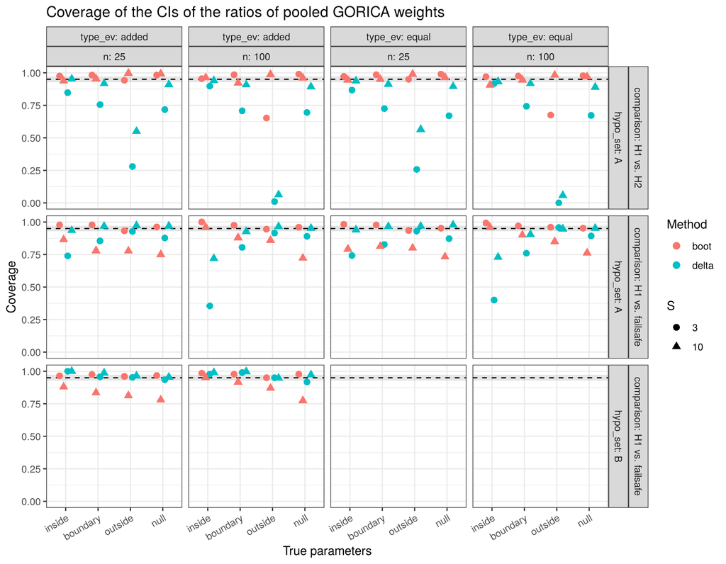

```r
plot_cov <- function(d, title) {
  ggplot(d, aes(x = theta, y = coverage, colour = method, shape = factor(S))) +
    annotate("rect", xmin = -Inf, xmax = Inf, ymin = .95 - 2 * mcse, ymax = .95 + 2 * mcse,
             alpha = .25, fill = "gray60") +
    geom_hline(yintercept = .95, linetype = "dashed") +
    geom_point(size = 2.5, position = position_dodge(width = .5)) +
    facet_grid(comparison + hypo_set ~ type_ev + n, labeller = label_both) +
    coord_cartesian(ylim = c(min(.5, min(d$coverage)), 1)) +
    labs(x = "True parameters", y = "Coverage", shape = "S", colour = "Method", title = title) +
    theme_bw() + theme(axis.text.x = element_text(angle = 30, hjust = 1))
}
plot_cov(subset(summ, quantity == "ratio"), "Coverage of the CIs of the ratios of pooled GORICA weights")
```

## 3.2 Differences in GORICA values

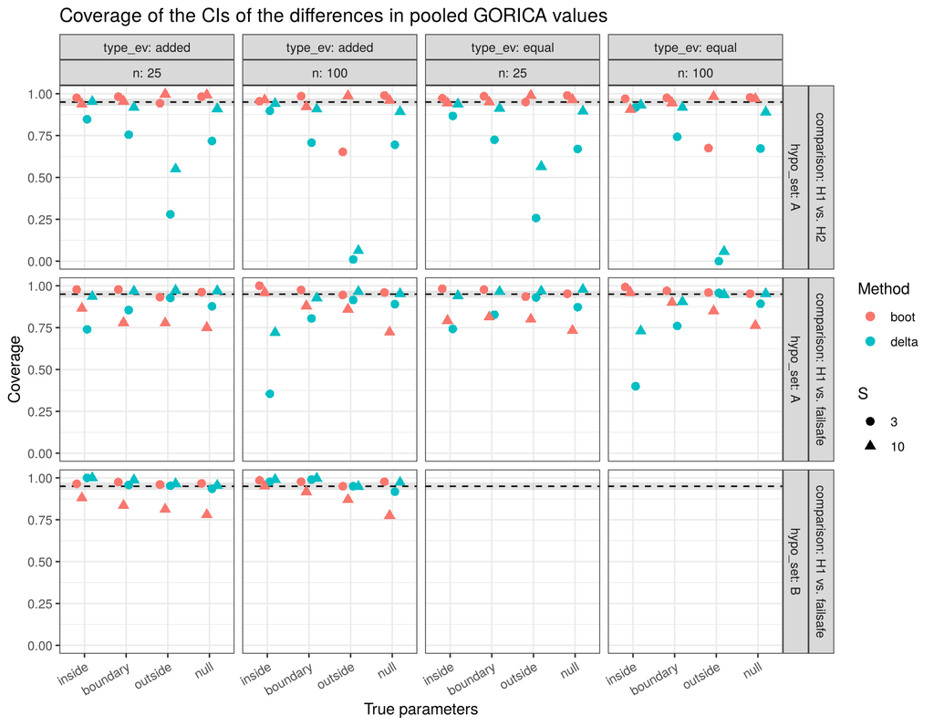

```r
plot_cov(subset(summ, quantity == "difference"), "Coverage of the CIs of the differences in pooled GORICA values")
```

## 3.3 GORICA weight of H1

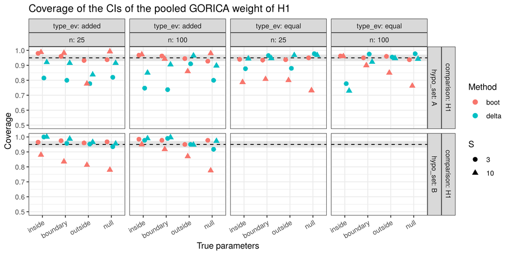

```r
plot_cov(subset(summ, quantity == "weight"), "Coverage of the CIs of the pooled GORICA weight of H1")
```

## 3.4 Tables

```r
tab <- summ[order(summ$quantity, summ$hypo_set, summ$comparison, summ$type_ev, summ$theta, summ$n, summ$S, summ$method), ]
tab$coverage <- round(tab$coverage, 3); tab$missing <- round(tab$missing, 3)
tab$median_width <- round(tab$median_width, 2)
knitr::kable(tab, row.names = FALSE)
```

| theta | n | S | type_ev | hypo_set | method | quantity | comparison | coverage | missing | median_width |
| --- | --- | --- | --- | --- | --- | --- | --- | --- | --- | --- |
| inside | 25 | 3 | added | A | boot | difference | H1 vs. H2 | 0.975 | 0.000 | 13.95 |
| inside | 25 | 3 | added | A | delta | difference | H1 vs. H2 | 0.848 | 0.007 | 13.31 |
| inside | 25 | 10 | added | A | boot | difference | H1 vs. H2 | 0.938 | 0.000 | 28.39 |
| inside | 25 | 10 | added | A | delta | difference | H1 vs. H2 | 0.953 | 0.000 | 26.32 |
| inside | 100 | 3 | added | A | boot | difference | H1 vs. H2 | 0.955 | 0.000 | 22.60 |
| inside | 100 | 3 | added | A | delta | difference | H1 vs. H2 | 0.897 | 0.000 | 22.28 |
| inside | 100 | 10 | added | A | boot | difference | H1 vs. H2 | 0.963 | 0.000 | 43.43 |
| inside | 100 | 10 | added | A | delta | difference | H1 vs. H2 | 0.940 | 0.000 | 41.70 |
| boundary | 25 | 3 | added | A | boot | difference | H1 vs. H2 | 0.983 | 0.000 | 8.37 |
| boundary | 25 | 3 | added | A | delta | difference | H1 vs. H2 | 0.755 | 0.140 | 7.92 |
| boundary | 25 | 10 | added | A | boot | difference | H1 vs. H2 | 0.955 | 0.000 | 17.42 |
| boundary | 25 | 10 | added | A | delta | difference | H1 vs. H2 | 0.917 | 0.005 | 14.62 |
| boundary | 100 | 3 | added | A | boot | difference | H1 vs. H2 | 0.985 | 0.000 | 8.41 |
| boundary | 100 | 3 | added | A | delta | difference | H1 vs. H2 | 0.708 | 0.155 | 7.49 |
| boundary | 100 | 10 | added | A | boot | difference | H1 vs. H2 | 0.922 | 0.000 | 18.40 |
| boundary | 100 | 10 | added | A | delta | difference | H1 vs. H2 | 0.907 | 0.000 | 15.01 |
| outside | 25 | 3 | added | A | boot | difference | H1 vs. H2 | 0.943 | 0.000 | 2.49 |
| outside | 25 | 3 | added | A | delta | difference | H1 vs. H2 | 0.280 | 0.708 | 3.73 |
| outside | 25 | 10 | added | A | boot | difference | H1 vs. H2 | 0.998 | 0.000 | 5.49 |
| outside | 25 | 10 | added | A | delta | difference | H1 vs. H2 | 0.550 | 0.375 | 3.28 |
| outside | 100 | 3 | added | A | boot | difference | H1 vs. H2 | 0.652 | 0.000 | 0.12 |
| outside | 100 | 3 | added | A | delta | difference | H1 vs. H2 | 0.010 | 0.990 | 4.47 |
| outside | 100 | 10 | added | A | boot | difference | H1 vs. H2 | 0.988 | 0.000 | 1.31 |
| outside | 100 | 10 | added | A | delta | difference | H1 vs. H2 | 0.062 | 0.938 | 2.21 |
| null | 25 | 3 | added | A | boot | difference | H1 vs. H2 | 0.983 | 0.000 | 7.47 |
| null | 25 | 3 | added | A | delta | difference | H1 vs. H2 | 0.718 | 0.200 | 7.31 |
| null | 25 | 10 | added | A | boot | difference | H1 vs. H2 | 0.993 | 0.000 | 15.06 |
| null | 25 | 10 | added | A | delta | difference | H1 vs. H2 | 0.910 | 0.002 | 12.29 |
| null | 100 | 3 | added | A | boot | difference | H1 vs. H2 | 0.990 | 0.000 | 6.97 |
| null | 100 | 3 | added | A | delta | difference | H1 vs. H2 | 0.695 | 0.202 | 6.49 |

[output cut: 386 more lines]

## 3.5 Overall summary

```r
overall <- aggregate(cbind(coverage = covered, missing = missing) ~ method + quantity, data = res, FUN = mean)
overall$coverage <- round(overall$coverage, 3); overall$missing <- round(overall$missing, 3)
knitr::kable(overall)
```

| method | quantity | coverage | missing |
| --- | --- | --- | --- |
| boot | difference | 0.920 | 0.00 |
| delta | difference | 0.813 | 0.12 |
| boot | ratio | 0.920 | 0.00 |
| delta | ratio | 0.813 | 0.12 |
| boot | weight | 0.914 | 0.00 |
| delta | weight | 0.914 | 0.00 |

# 4 Diagnostics: degenerate CIs

The coverage is evaluated strictly (the target value must lie in the CI). When both hypotheses have the same order-restricted MLEs in (nearly) all studies, the sampling distribution of their difference is (nearly) a point mass, and so is its CI; the expected value then differs from that point by a negligible amount, which a strict evaluation counts as non-coverage. For the condition with the lowest coverage for H1 versus H2 with $S$ = 3 (parameters in the opposite order, $n$ = 100), the CIs were recomputed while storing their bounds, and the coverage was also evaluated with a small tolerance (0.1 on the scale of the difference in GORICA values, i.e., about 5% on the scale of the ratio of weights):

```r
# Diagnostic for the evSyn_CI() condition with a low (strict) coverage for H1 versus H2
# (parameters in the opposite order, S = 3, n = 100): strict versus tolerant coverage and degenerate CIs.
suppressPackageStartupMessages(library(restriktor))
set.seed(5)
R <- 200; B <- 500; tol <- 0.1; S <- 3; n <- 100
th <- c(b1 = 0, b2 = .2, b3 = .4); V <- diag(1 / n, 3)
H <- list(H1 = "b1 > b2 > b3", H2 = "b1 > b2 = b3")
g0 <- goric(th, VCOV = V, hypotheses = H)
EIC <- colMeans(restriktor:::goric_CI_boot(g0, as.character(g0$result$model), B = 2e5))
target <- S * (EIC[1] - EIC[2])
b <- t(replicate(R, {
  est <- lapply(1:S, function(s) setNames(th + rnorm(3, 0, sqrt(1 / n)), names(th)))
  ci <- evSyn_CI(suppressMessages(evSyn(est, VCOV = rep(list(V), S), hypotheses = H)), B = B)$difference
  j <- which(ci$model == "H1" & ci$vs == "H2"); c(ci$lower[j], ci$upper[j])
}))
d <- data.frame(S = S, n = n, comparison = "H1 vs. H2", theta = "outside", target = target,
                strict = mean(b[, 1] <= target & target <= b[, 2]),
                tolerant = mean(b[, 1] - tol <= target & target <= b[, 2] + tol),
                degenerate = mean(b[, 2] - b[, 1] < 1e-6))
print(d, row.names = FALSE)
saveRDS(d, "diag_evSyn_CI.rds")
```

```r
knitr::kable(readRDS("diag_evSyn_CI.rds"), digits = 3, row.names = FALSE)
```

| S | n | comparison | theta | target | strict | tolerant | degenerate |
| --- | --- | --- | --- | --- | --- | --- | --- |
| 3 | 100 | H1 vs. H2 | outside | 1.996 | 0.645 | 1 | 0.315 |

So, this low (strict) coverage is an artifact of degenerate (point) CIs: with the tolerance, the coverage is 1. The undercoverage for the best hypothesis versus the failsafe with $S$ = 10 is not such an artifact: it is removed by centering the bootstrap draws (see the next section).

# 5 A possible improvement: centering the bootstrap

The undercoverage of the bootstrap with $S$ = 10 studies has a clear cause. For a difference in GORICA values $T$, the bootstrap draws $T^*$ (around the estimates) are shifted relative to the sampling distribution of $T$ (around the true parameters): in a study, the projection of a bootstrap draw adds, on average, roughly the number of active restrictions to $D_m$ (see also `?goric_CI`). In one study, this shift is small relative to the spread of $T$. In the pooled results, however, the shifts add up over the studies (they grow with $S$), whereas the spread grows with $\sqrt{S}$ only. Hence, the percentile CI is increasingly shifted with more studies.

A natural correction is to center the bootstrap draws: estimate the shift by $\bar{T}^* - T_{obs}$ and remove it. Two versions were evaluated in a smaller simulation (the pooled difference H1 versus the failsafe, added evidence, $n$ = 25, R = 250, B = 500), using the same bootstrap draws for all three versions:

- `percentile`: the current CI, the percentiles of $T^*$;
- `centered_perc`: $T_{obs} + [q_{.025}, q_{.975}]$ of $Z = T^* - \bar{T}^*$;
- `centered_basic`: $T_{obs} - [q_{.975}, q_{.025}]$ of $Z = T^* - \bar{T}^*$ (reversed, as in the basic bootstrap).

```r
suppressPackageStartupMessages(library(restriktor))
set.seed(11)
R <- 250; B <- 500
thetas <- list(null = c(b1 = 0, b2 = 0, b3 = 0), boundary = c(b1 = .2, b2 = 0, b3 = 0),
               outside = c(b1 = 0, b2 = .2, b3 = .4), inside = c(b1 = .4, b2 = .2, b3 = 0))
hs <- list(A = list(H1 = "b1 > b2 > b3", H2 = "b1 > b2 = b3"), B = list(H1 = "b1 > b2 > b3"))
out <- list()
for (hn in names(hs)) for (tn in names(thetas)) for (S in c(3, 10)) {
  n <- 25; V <- diag(1 / n, 3); th <- thetas[[tn]]
  g0 <- goric(th, VCOV = V, hypotheses = hs[[hn]]); mods <- as.character(g0$result$model); M <- length(mods)
  EIC <- colMeans(restriktor:::goric_CI_boot(g0, mods, B = 1e5))
  target <- S * (EIC[1] - EIC[M])                         # pooled difference H1 vs failsafe (added)
  cov <- matrix(NA, R, 3, dimnames = list(NULL, c("percentile", "centered_perc", "centered_basic")))
  for (r in 1:R) {
    Tobs <- 0; Tb <- 0
    for (s in 1:S) {
      g <- goric(th + rnorm(3, 0, sqrt(1 / n)), VCOV = V, hypotheses = hs[[hn]])
      ICb <- restriktor:::goric_CI_boot(g, mods, B = B)
      Tobs <- Tobs + (g$result$gorica[1] - g$result$gorica[M])
      Tb <- Tb + (ICb[, 1] - ICb[, M])
    }
    q <- quantile(Tb, c(.025, .975)); Z <- Tb - mean(Tb)
    qz <- quantile(Z, c(.025, .975))
    cov[r, ] <- c(q[1] <= target & target <= q[2],
                  Tobs + qz[1] <= target & target <= Tobs + qz[2],
                  Tobs - qz[2] <= target & target <= Tobs - qz[1])
  }
  out[[length(out) + 1]] <- data.frame(set = hn, theta = tn, S = S, t(colMeans(cov)))
  print(tail(out, 1)[[1]], row.names = FALSE)
}
saveRDS(do.call(rbind, out), "proto_centered.rds")
```

```r
proto <- readRDS("proto_centered.rds")
knitr::kable(proto, digits = 3, row.names = FALSE,
             caption = "Coverage of the CI of the pooled difference H1 versus the failsafe")
```

Coverage of the CI of the pooled difference H1 versus the failsafe

| set | theta | S | percentile | centered_perc | centered_basic |
| --- | --- | --- | --- | --- | --- |
| A | null | 3 | 0.956 | 1.000 | 0.916 |
| A | null | 10 | 0.760 | 0.992 | 0.992 |
| A | boundary | 3 | 0.968 | 1.000 | 0.888 |
| A | boundary | 10 | 0.804 | 1.000 | 0.992 |
| A | outside | 3 | 0.960 | 0.980 | 0.920 |
| A | outside | 10 | 0.808 | 0.968 | 0.960 |
| A | inside | 3 | 0.988 | 1.000 | 0.928 |
| A | inside | 10 | 0.792 | 1.000 | 1.000 |
| B | null | 3 | 0.964 | 1.000 | 0.960 |
| B | null | 10 | 0.752 | 1.000 | 0.988 |
| B | boundary | 3 | 0.952 | 0.996 | 1.000 |
| B | boundary | 10 | 0.808 | 1.000 | 1.000 |
| B | outside | 3 | 0.932 | 0.992 | 0.920 |
| B | outside | 10 | 0.780 | 0.984 | 0.984 |
| B | inside | 3 | 0.960 | 0.996 | 1.000 |
| B | inside | 10 | 0.888 | 1.000 | 1.000 |

Centering removes the undercoverage with $S$ = 10 (coverage .96 to 1.00), but neither centered version is uniformly good: the centered percentile version is conservative in nearly all conditions (coverage close to 1, so the CIs are too wide), and the centered basic version undercovers somewhat with $S$ = 3 in some conditions (.89 to .92). The reason is that, near the boundaries of the hypotheses, the shift (and the shape of the distribution) depends on where the true parameters are, so it is not estimated exactly by the shift at the estimates. This is the same reason why `goric_CI()` uses an inversion of the sampling distribution where possible.

# 6 Conclusions

The coverages (ranges over all conditions) are:

- ratios of weights: bootstrap 0.652 to 1.000; delta method 0.000 to 1.000;
- differences in GORICA values: bootstrap 0.652 to 1.000; delta method 0.000 to 1.000;
- weight of H1: bootstrap 0.733 to 0.993; delta method 0.730 to 1.000.

**Recommendations.**

- Keep the bootstrap as the default of `evSyn_CI()`, but note in the documentation that its CIs can be (too) narrow when many studies are pooled, especially for the best hypothesis versus the failsafe and when the true parameters are on the boundary of the hypotheses.
- With many studies, a centered bootstrap removes most of the undercoverage (see the previous section). It could be offered as an option (or as the default for, say, $S \geq 5$), but it is conservative or slightly anti-conservative in some conditions, so this choice deserves a further look (e.g., a pooled version of the inversion method of `goric_CI()`).
- Use the delta method only for clearly distinguishable hypotheses (no overlap in any study).

# 7 Session information

```r
sim$sessionInfo
```

[output not shown]